# communicate_data_findings_deck

## TMDB Movies Dataset - Data Exploration & Visualization

### Introduction & Overview

**Investigation Overview**

> In this investigation, I wanted to look at the features associated with a movie. There are movies made over the years costing more than hundred million dollars, yet they tend to flop. Many of the underrated movies tend to perfom good and receive good reviews and ratings. The Goal here is to understand these features associated and study the phenomenon why million dollar movies tends to flop.

**Dataset Description**

> *Dataset URL : https://www.kaggle.com/tmdb/tmdb-movie-metadata The Dataset contains 5000+ movie data containing data of major films costing over 100 million dollars to produce, which can still flop, this question is more important than ever to the industry. It is expected that after reading and analysing this particular dataset we would be able to answer some of the more important questions revolving around film industry.* The dataset has 10866 rows and 21 columns.

```python
# import all the necessary libraries
import numpy as np
import pandas as pd
import matplotlib.pyplot as plt
import seaborn as sns

%matplotlib inline

# suppress warnings from final output
import warnings
warnings.simplefilter("ignore")
```

```python
# loading the cleaned datasets
cleaned_df = pd.read_csv('/content/drive/MyDrive/Notebook/communicate_data/cleaned_df.csv')
# loading the genres  dataset
genres_df = pd.read_csv('/content/drive/MyDrive/Notebook/communicate_data/genres_split.csv')
```

```python
cleaned_df.head()
```

|  | popularity | profit_adj | profit | budget | revenue | original_title | director | runtime | genres | production_companies | release_date | vote_count | vote_average | release_year | budget_adj | revenue_adj | profit_or_loss |
| --- | --- | --- | --- | --- | --- | --- | --- | --- | --- | --- | --- | --- | --- | --- | --- | --- | --- |
| 0 | 32.985763 | 1.254446e+09 | 1363528810 | 150000000 | 1513528810 | Jurassic World | Colin Trevorrow | 124 | Action\|Adventure\|Science Fiction\|Thriller | Universal Studios\|Amblin Entertainment\|Legenda... | 6/9/15 | 5562 | 6.5 | 2015 | 1.379999e+08 | 1.392446e+09 | profit |
| 1 | 28.419936 | 2.101614e+08 | 228436354 | 150000000 | 378436354 | Mad Max: Fury Road | George Miller | 120 | Action\|Adventure\|Science Fiction\|Thriller | Village Roadshow Pictures\|Kennedy Miller Produ... | 5/13/15 | 6185 | 7.1 | 2015 | 1.379999e+08 | 3.481613e+08 | profit |
| 2 | 13.112507 | 1.704191e+08 | 185238201 | 110000000 | 295238201 | Insurgent | Robert Schwentke | 119 | Adventure\|Science Fiction\|Thriller | Summit Entertainment\|Mandeville Films\|Red Wago... | 3/18/15 | 2480 | 6.3 | 2015 | 1.012000e+08 | 2.716190e+08 | profit |
| 3 | 11.173104 | 1.718723e+09 | 1868178225 | 200000000 | 2068178225 | Star Wars: The Force Awakens | J.J. Abrams | 136 | Action\|Adventure\|Science Fiction\|Fantasy | Lucasfilm\|Truenorth Productions\|Bad Robot | 12/15/15 | 5292 | 7.5 | 2015 | 1.839999e+08 | 1.902723e+09 | profit |
| 4 | 9.335014 | 1.210949e+09 | 1316249360 | 190000000 | 1506249360 | Furious 7 | James Wan | 137 | Action\|Crime\|Thriller | Universal Pictures\|Original Film\|Media Rights ... | 4/1/15 | 2947 | 7.3 | 2015 | 1.747999e+08 | 1.385749e+09 | profit |

```python
genres_df.head()
```

|  | popularity | profit | budget | revenue | original_title | director | runtime | genres | production_companies | release_date | vote_count | vote_average | release_year | budget_adj | revenue_adj |
| --- | --- | --- | --- | --- | --- | --- | --- | --- | --- | --- | --- | --- | --- | --- | --- |
| 0 | 32.985763 | 1363528810 | 150000000 | 1513528810 | Jurassic World | Colin Trevorrow | 124 | Action | Universal Studios\|Amblin Entertainment\|Legenda... | 6/9/15 | 5562 | 6.5 | 2015 | 1.379999e+08 | 1.392446e+09 |
| 1 | 32.985763 | 1363528810 | 150000000 | 1513528810 | Jurassic World | Colin Trevorrow | 124 | Adventure | Universal Studios\|Amblin Entertainment\|Legenda... | 6/9/15 | 5562 | 6.5 | 2015 | 1.379999e+08 | 1.392446e+09 |
| 2 | 32.985763 | 1363528810 | 150000000 | 1513528810 | Jurassic World | Colin Trevorrow | 124 | Science Fiction | Universal Studios\|Amblin Entertainment\|Legenda... | 6/9/15 | 5562 | 6.5 | 2015 | 1.379999e+08 | 1.392446e+09 |
| 3 | 32.985763 | 1363528810 | 150000000 | 1513528810 | Jurassic World | Colin Trevorrow | 124 | Thriller | Universal Studios\|Amblin Entertainment\|Legenda... | 6/9/15 | 5562 | 6.5 | 2015 | 1.379999e+08 | 1.392446e+09 |
| 4 | 28.419936 | 228436354 | 150000000 | 378436354 | Mad Max: Fury Road | George Miller | 120 | Action | Village Roadshow Pictures\|Kennedy Miller Produ... | 5/13/15 | 6185 | 7.1 | 2015 | 1.379999e+08 | 3.481613e+08 |

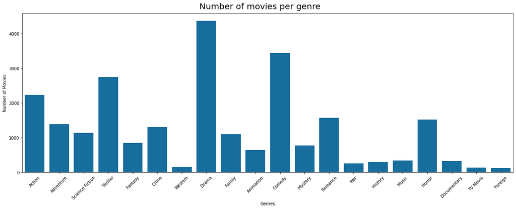

```python
# visualize which genre holds the highest number of movies
base_color = sns.color_palette('colorblind')[0]
plt.figure(figsize=(21, 7));
plt.figtext(.5,.9,'Number of movies per genre', fontsize=20, ha='center')
plt.xticks(rotation=45);
sns.countplot(genres_df.genres, color=base_color);
plt.xlabel('Genres')
plt.ylabel('Number of Movies')
plt.show();
```

Top movie Genres 1960 - 2015

*Genre 'Drama' holds the maximum number of movies in this dataset, which is above 400 movies over the years from 1960 - 2015.*

**Top 3 Genres of maximum movies -**

1. Drama
2. Comedy
3. Thriller

**Number of movies over the course if years**

> Over the course of these years from 1960 - 2015 the number of movies have increased gradually. The year 2014 is holding the maximum number of movies released in this dataset, which is more than 600.

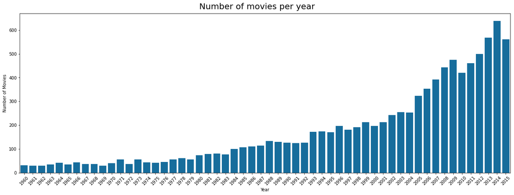

```python
# the number of movies released per year
# countplot
base_color = sns.color_palette('colorblind')[0]
plt.figure(figsize=(21, 7));
plt.figtext(.5,.9,'Number of movies per year', fontsize=20, ha='center');
plt.xticks(rotation=45);
sns.countplot(cleaned_df.release_year, color=base_color);
plt.xlabel('Year')
plt.ylabel('Number of Movies')
plt.show();
```

Runtime plays a significant role in a movie. Over the years and depending on movie to movie we have seen a runtime of a movie to vary. The details found in this dataset are as follows:

> 1. Average runtime of movies is 102 min
> 2. 25% movies have runtime less than 90 minutes
> 3. 50% movies have runtime less than 100 minutes
> 4. 75% movies have runtime less than 112 minutes
> 5. Min runtime is 0 minutes
> 6. Max runtime is 877 minutes

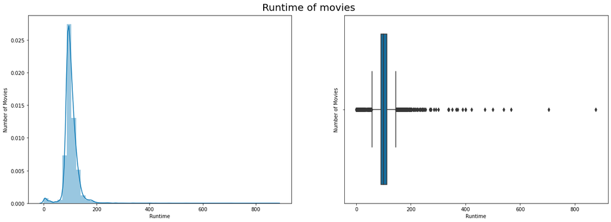

```python
# the relation of length of the movies over the years
# plot histogram
base_color = sns.color_palette('colorblind')[0]
plt.figure(figsize=(21, 7));
plt.figtext(.5,.9,'Runtime of movies', fontsize=20, ha='center');
plt.xticks(rotation=45);
plt.subplot(1, 2, 1)
sns.distplot(cleaned_df.runtime, hist=True, kde=True, color=base_color)
plt.xlabel('Runtime')
plt.ylabel('Number of Movies')
plt.subplot(1, 2, 2)
# boxplot
sns.boxplot(cleaned_df.runtime, color=base_color)
plt.xlabel('Runtime')
plt.ylabel('Number of Movies')
plt.show();
```

**Average rating per year**

> Observing the plot closely it can be stated that the Average rating per year has decreased. Both plots state the decrease where as the line plot we see significant fluctuations in the graph and we see more spikes to confirm our statement.

```python
# Declaring groupby function for code reuse
def group_by_avg(feature1,feature2):
    #This function will calculate mean
    gba = cleaned_df.groupby(feature1)[feature2].mean()
    return gba
```

```python
# We will try to understand how old movies are receiving ratings over time
avg_movie_rating_per_year = group_by_avg("release_year","vote_average")
avg_movie_rating_per_year.head()
```

```
release_year
1960    6.325000
1961    6.433333
1962    6.386667
1963    6.329412
1964    6.224390
Name: vote_average, dtype: float64
```

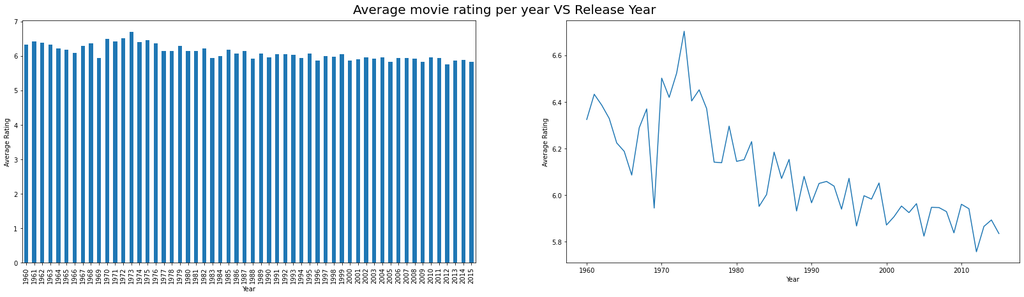

```python
plt.figure(figsize=(28, 7));
plt.figtext(.5,.9,'Average movie rating per year VS Release Year', fontsize=20, ha='center');
plt.subplot(1, 2, 1)
avg_movie_rating_per_year.plot(kind='bar')
#x-axis name
plt.xlabel('Year')
#y-axis name
plt.ylabel('Average Rating')
plt.subplot(1, 2, 2)
avg_movie_rating_per_year.plot(kind='line')
#x-axis name
plt.xlabel('Year')
#y-axis name
plt.ylabel('Average Rating')
```

**Average Profit over the years**

> Clearly from both the plots we can conclude that the average profit has increased quite significantly. But there is another side to this story. Direct comparison of '$' value over the course of years is not very natural. This is because in 1960 the living cost was significantly lower than the living cost of 2015. Similarly in 1960 one could buy a lot more with one dollar than can buy today. Hence we introduced another feature profit_adj which is adjusted profit whose value is adjusted revenue minus adjusted budget. We observed that as year increased, the adjusted profit has decreased. We found the line of trend to be negatively sloped.

```python
# Let us try to understand how the industry is performing over the years
# Calculate the mean of profit for each year
avg_profit_per_year = group_by_avg('release_year','profit')
avg_profit_per_year.head()
```

```
release_year
1960    3.842127e+06
1961    9.719440e+06
1962    5.361924e+06
1963    3.355103e+06
1964    7.353625e+06
Name: profit, dtype: float64
```

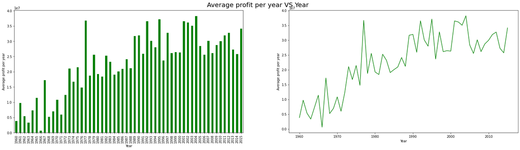

```python
# Plotting graph for understanding the average profit per year visually
plt.figure(figsize=(28, 7));
plt.figtext(.5,.9,'Average profit per year VS Year', fontsize=20, ha='center');
plt.subplot(1, 2, 1)
avg_profit_per_year.plot(kind='bar', color='green')
# x-axis name
plt.xlabel('Year')
# y-axis name
plt.ylabel('Average profit per year')

# Plotting line graph for understanding the average profit per year visually
plt.subplot(1, 2, 2)
avg_profit_per_year.plot(kind='line', color='green')
# x-axis name
plt.xlabel('Year')
# y-axis name
plt.ylabel('Average profit per year')
```

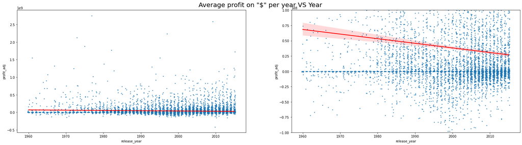

```python
plt.figure(figsize=(28, 7));
plt.figtext(.5,.9,'Average profit on "$" per year VS Year', fontsize=20, ha='center');
# Now plotting the adjusted values
plt.subplot(1, 2, 1)
sns.regplot(data=cleaned_df, x='release_year', y='profit_adj', line_kws={'color':'red'},scatter_kws={'s':3}, x_jitter=0.25)
plt.subplot(1, 2, 2)
sns.regplot(data=cleaned_df, x='release_year', y='profit_adj', line_kws={'color':'red'},scatter_kws={'s':3}, x_jitter=0.25)
plt.ylim(-10**8,10**8);
```

**Most popular Genre**

> Adventure seems to be the most popular genre amongst others, holding the number 1 position in terms of popularity form 1960 - 2015. Other positions are held by Science Fiction which is 2nd and Fantasy as 3rd.

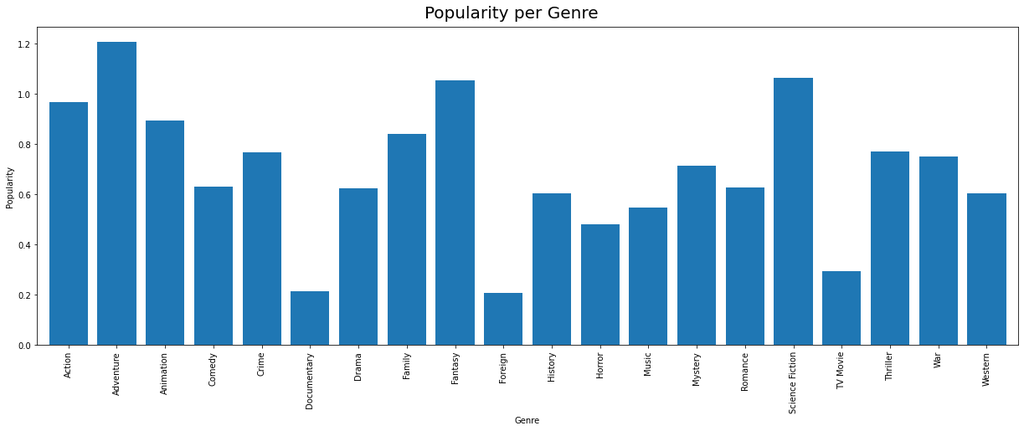

```python
# barplot
plt.figure(figsize=(21, 7));
plt.figtext(.5,.9,'Popularity per Genre', fontsize=20, ha='center');
genres_df.groupby('genres').popularity.mean().plot.bar(width=0.8, xlabel="Genre", ylabel="Popularity")
```

**Spread of Profit/Loss on every genre over the years**

> Variations in the profit feature clearly states that there are values which are below 0, depicting a loss. Therse indicates loss which were suppressed earlier. The genres where we observed loss significantly are westers, foreign and tv movie.

```python
# to understand the relation between release year, genre and profit
# creating pivot table with the required features
genre_pivot = genres_df.pivot_table(values='profit',index='release_year',columns='genres')
genre_pivot.dropna(inplace=True)
```

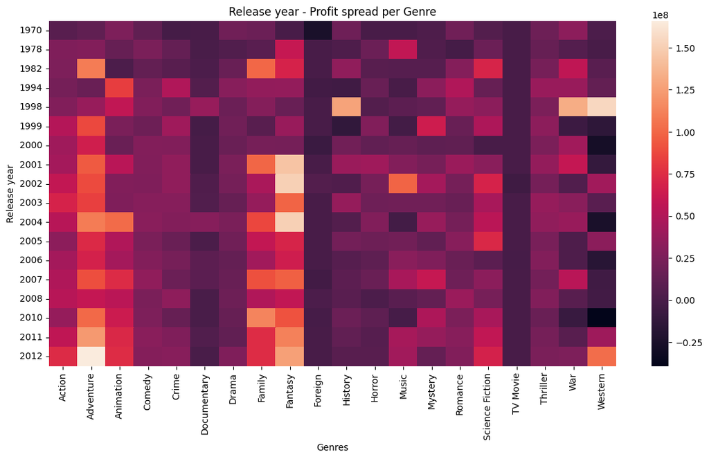

```python
# plotting heatmap of the generated pivot
plt.figure(figsize=(14,7), dpi=100)
sns.heatmap(genre_pivot).set_title('Release year - Profit spread per Genre')
plt.xlabel('Genres')
plt.ylabel('Release year')
```

**Spread of Profit / Loss**

> To understand the spread of profit / loss in the dataset more closely we introduced a new feature to hold category values if there is a profit, or loss or the movie just was able to collect cost price and make no profit or loss. We found 39.12 % of the movies are made at cost, which means no profit, no loss. where as 37.74 % of the movies could make a profit. And 23.14 % of the movies have made a loss.

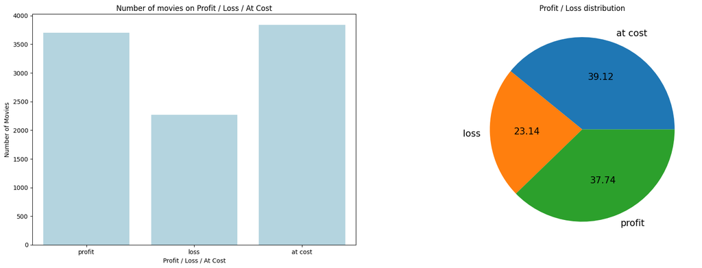

```python
# Spread of Profit/loss
plt.figure(figsize=(21,7), dpi=100)
plt.subplot(1, 2, 1)
sns.countplot(x ='profit_or_loss', data = cleaned_df, color = 'lightblue').set_title('Number of movies on Profit / Loss / At Cost')
plt.xlabel('Profit / Loss / At Cost')
plt.ylabel('Number of Movies')
plt.subplot(1, 2, 2)
cleaned_df.groupby('profit_or_loss').size().plot(kind='pie', textprops={'fontsize': 15}, autopct='%.2f', ylabel="", title="Profit / Loss distribution")
```

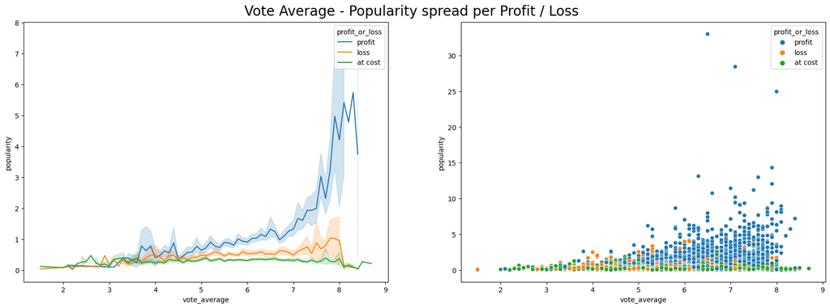

```python
# to understand on these categories of profit_or_loss
# how are average vote and popularity spread across
plt.figure(figsize=(21,7), dpi=100)
plt.figtext(.5,.9,'Vote Average - Popularity spread per Profit / Loss', fontsize=20, ha='center');
plt.subplot(1, 2, 1)
sns.lineplot(x="vote_average", y="popularity", data=cleaned_df, hue='profit_or_loss')
plt.subplot(1, 2, 2)
sns.scatterplot(x="vote_average", y="popularity", data=cleaned_df, hue='profit_or_loss')
```

**Combining data from pie plot and line graph we can state that**

> 1. 23.14 % of the movies made a loss even with average vote more than 5.5 and with low popularity
> 2. 39.12 % of the movies made no gain no loss even with average vote more than 5.5 and with low popularity
> 3. 37.74 % of the movies made profit with average vote more than 6 and with high popularity.

### Summary

> 23.14 % of the movies made a loss, 39.12 % of the movies made no gain no loss, 37.74 % of the movies made profit. Over the years there is a increase in profit in terms of numerical dollar value, but when thinking in terms of actual dollar value since Direct comparison of dollar value over the course of years is not very natural, since in 1960 one could buy a lot more than what he can buy in 2015. Considering this fact in the analysis we observed a negative slope in the line of trends.Maximum number of movies were made with genre 'Drama' where as Most popular genre among the viewers as Adventure. Now we also have observed that genres such as Western, Tv movie, Foreign has generates the most loss. Popularity plays a very important role for a movie to be successful and generate profit. The more the popularity is of a movie, it tends to generate more revenue as a linear relation it can generate more profit. Now since Adventure genre is already a popular genre, movies in this genre tends to perform well in terms of revenue & profit.